# (Fasaha Capstone Project)

# RELATIONSHIP BETWEEN COUNTRY,NUMBER OF CATALOG PURCHASES AND ACCEPTED CAMPAIGN(2,4,6)

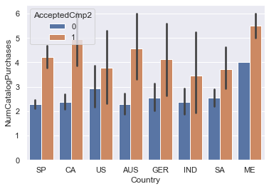

```python
sns.barplot(x="Country", y="NumCatalogPurchases",hue="AcceptedCmp2",data=data)
```

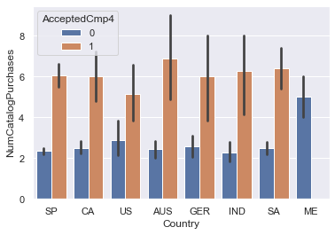

```python
sns.barplot(x="Country", y="NumCatalogPurchases",hue="AcceptedCmp4",data=data)
```

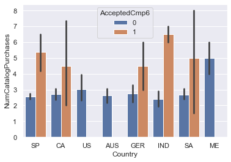

```python
sns.barplot(x="Country", y="NumCatalogPurchases",hue="AcceptedCmp6",data=data)
```

OBSERVATION:People living in India and bought more than 6 products,accepted the campaign more. while people livivng in Australia, US and mexico didn't accept the campaign

# RELATIONSHIP BETWEEN EDUCATION AND PRODUCT PURCHASED

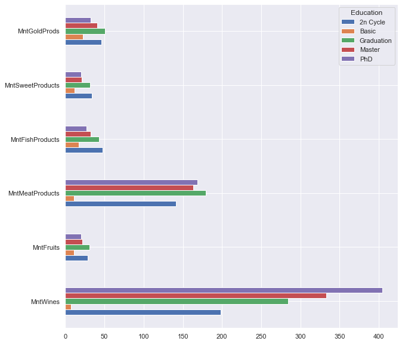

```python
data.groupby('Education')[['MntWines', 'MntFruits', 'MntMeatProducts', 'MntFishProducts', 'MntSweetProducts', 'MntGoldProds']].mean().T.plot(kind='barh', figsize=(10,10))
```

# RELATIONSHIP BETWEEN TEENEGERS AT HOME,NUMBER OFSTORE PURCHASES AND ACCEPTED CAMPAIGN(2,4,6)

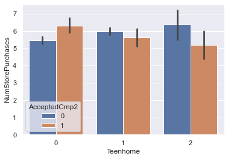

```python
sns.barplot(x="Teenhome", y="NumStorePurchases",hue="AcceptedCmp2",data=data)
```

OBSERVATION: People without teenagers that get their products from the store accepted campaign more and they are still the same group of people with the least acceptance rate

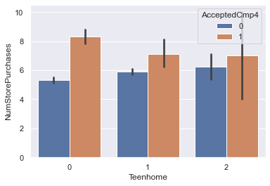

```python
sns.barplot(x="Teenhome", y="NumStorePurchases",hue="AcceptedCmp4",data=data)
```

OBSERVATION: People without teenagers that get their products from the store accepted campaign more and they are still the same group of people with the least acceptance rate

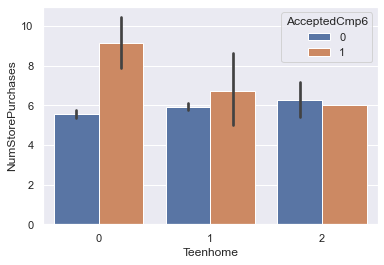

```python
sns.barplot(x="Teenhome", y="NumStorePurchases",hue="AcceptedCmp6",data=data)
```

OBSERVATION: People without teenagers that get their products from the store accepted campaign more and they are still the same group of people with the least acceptance rate

# RELATIONSHIP BETWEEN SMALL KIDS AT HOME,NUMBER OF WEB PURCHASES AND ACCEPTED CAMPAIGN(2,4,6)

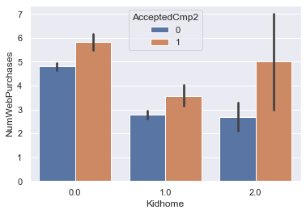

```python
sns.barplot(x="Kidhome", y="NumWebPurchases",hue="AcceptedCmp2",data=data)
```

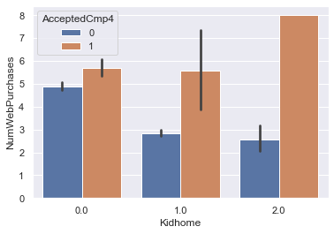

```python
sns.barplot(x="Kidhome", y="NumWebPurchases",hue="AcceptedCmp4",data=data)
```

OBSERVATION: People with two kids that get their products from the website accepted the campaign more and they are still the same group of people with the least acceptance rate

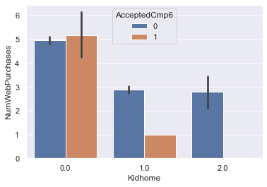

```python
sns.barplot(x="Kidhome", y="NumWebPurchases",hue="AcceptedCmp6",data=data)
```

# RELATIONSHIP BETWEEN EDUCATION,NUMBER OF WEB VISIT IN THE LAST MONTH AND ACCEPTED CAMPAIGN(2,4,6)

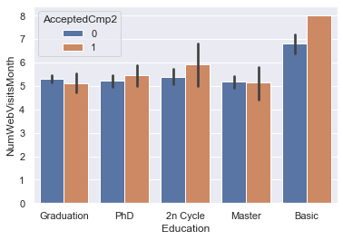

```python
sns.barplot(x="Education", y="NumWebVisitsMonth",hue="AcceptedCmp2",data=data)
```

OBSERVATION: People with basic education that get their products from the website accepted the campaign more while, people with masters least accepted the campaign

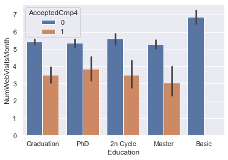

```python
sns.barplot(x="Education", y="NumWebVisitsMonth",hue="AcceptedCmp4",data=data)
```

OBSERVATION: People with PhD that get their products from the website accepted the campaign more while, people with basic education did not accept the campaign

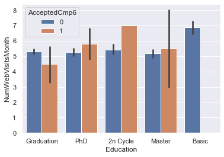

```python
sns.barplot(x="Education", y="NumWebVisitsMonth",hue="AcceptedCmp6",data=data)
```

OBSERVATION: People in 2n cycle education that get their products from the website the accepted campaign more while, people with basic education did not accept the campaign

# RECOMMENDATION